# R Notebook

# Tema seleccionado:

## **Efectos de la pandemia en el desempeño de los estudiantes universitarios.**

# Título del trabajo:

### **Principales efectos en el desempeño académico de los estudiantes universitarios durante el ciclo 2021-1 en la universidad UTEC generado por la pandemia.**

## **Introducción**

#### **Relevancia:**

#### Debido a la coyuntura que sigue enfrentando el mundo desde que comenzó la pandemia del covid-19 en el año 2020 todos nos vimos en la obligación de aislarnos en nuestros hogares con el fin de prevenir la transmisión del virus. Esto tuvo gran impacto sobre todos los países, tanto en la economía como en la educación. Debido a la problemática de la pandemia la educación se vio obligada a ser adaptada a la virtualidad. El Perú también sufrió este proceso en gran parte, universidades, institutos y algunos colegios en su mayoría particulares implementaron las clases virtuales. Por otro lado, la virtualidad no llegó a casi toda la nación, en su mayoría a estudiantes de bajos recursos y los que viven en provincia. Esto tuvo grandes efectos en el sector educativo de nuestro país, por ejemplo, en cuanto a la asistencia a las clases, según un informe del IPE (2021) la asistencia se redujo de un 92% a un 87% en el 2020. Efectos de la pandemia en el desempeño de los estudiantes universitarios. Es gracias a esto que a nuestro grupo le surgió el interés por estudiar los efectos y la influencia que tuvo toda esta situación en el desempeño de los alumnos. Por todo lo mencionado anteriormente, el equipo se plantea el siguiente problema:

#### **¿**Cuáles son los principales efectos en el desempeño académico de los estudiantes universitarios durante el ciclo 2021-1 en la universidad UTEC generado por la pandemia **?**

#### Por lo que nos hemos planteado los siguientes objetivos:

#### La influencia de la pandemia/virtualidad en específico para cada carrera universitaria.

#### Estudiar la relación entre el desempeño de los estudiantes y su frecuencia.

#### La influencia de la pandemia/virtualidad en general para las carreras universitarias.

#### Analizar la influencia de la pandemia en la salud y su relación con el desempeño.

#### La relación entre la clase económica y el desempeño académico.

#### Analizar porcentualmente la relación de la clase económica específica con el desempeño académico.

#### Estudiar la correlación entre el desempeño y la cantidad de cursos jalados.

#### **Planificación:**

```r
library(Publish)
```

```r
library(ggplot2)
library(ggthemes)
library(readr)
```

## **Datos**

#### **Proceso de recolección de datos:**

#### Una de las partes más importantes de un estudio estadístico es la delimitación de la población muestral ya que influirá de manera drástica los resultados posibles que se podrán hallar durante la investigación. En nuestro caso, nosotros quisimos dirigir nuestro estudio exclusivamente hacia los estudiantes universitarios de UTEC debido a que somos miembros de esta comunidad universitaria, lo cual facilita la recolección de datos requerida. Esto se debe a que tenemos medios de comunicación en común, así como formas de llegar al mayor número de estudiantes posibles, lo cual se nos hubiese dificultado más si se hubiera elegido otra institución de educación superior. Una vez que tenemos identificada a la población de dónde se hallará nuestra muestra representativa, realizamos el muestreo aleatorio simple delimitando aún más la población muestral. Se decidió que serían todos los estudiantes de UTEC desde el tercer ciclo hasta el décimo ciclo y fuimos seleccionando a los alumnos al azar hasta llegar a la muestra requerida. Los alumnos que cursan el primer y segundo ciclo no habían comenzado en el periodo 2021-1, por ello no experimentaron la etapa más crítica de la pandemia donde las restricciones fueron más severas y la virtualidad tuvo mayor presencia.

#### Para el proceso de recolección de datos se emplearon diversos métodos y estrategias de obtención de datos. Primero realizamos una encuesta considerando las variables necesarias que nos ayudarán en nuestro estudio. Luego lo difundimos por medio de las redes sociales de la universidad, como por ejemplo, en grupos de diversas carreras y cursos, para que de esta manera llegue a la mayor cantidad de personas y estos puedan responder voluntariamente. Todo esto con la intención de llegar a una muestra representativa que nos permita obtener conclusiones precisas y válidas.

#### Por último la finalidad de nuestro estudio consiste en poder conocer cómo fue el desempeño de los alumnos en la etapa de la educación virtual obligatoria y como la pandemia logró mejorar o empeorar su desempeño universitario.

#### Esta encuesta la realizamos en Google Forms debido a que para nosotros resultó ser la forma más sencilla para llevarla a cabo ya que iba a ser distribuida de manera virtual entre la comunidad de estudiantes.

#### [Link del cuestionario](https://docs.google.com/forms/d/e/1FAIpQLSdvqD5d9HJ5Xp0BQ5n_sp-DzxPuPVkKw8GSamivBue53EBaLA/viewform?usp=sf_link)

#### **Población:**

#### En este proceso definimos como nuestra población de estudio a los estudiantes de UTEC que se encuentren en el 3er ciclo en adelante, ya que esta población curso el periodo 2021-1.

#### **Muestra:**

#### En esta oportunidad usaremos una muestra que abarca un total de 200 estudiantes de las diferentes carreras y ciclos de la Universidad, sin embargo, en este caso la representatividad de nuestra muestra se ve ligeramente condicionada a nuestro entorno social. Esto se debe a que la mayor parte del grupo se encuentran cursando el tercer o cuarto ciclo la mayor parte de los encuestados serán estudiantes de ciclos similares.

#### **Muestreo:**

#### El tipo de muestreo sería aleatorio simple, ya que nosotros no seleccionamos un grupo en específico, si no que el muestreo es completamente aleatorio y buscamos encuestar a la mayor cantidad de estudiantes posibles sin importar su carrera o ciclo para poder llegar a una cantidad exacta que nos favorezca en los resultados y sacar conclusiones exacta, exceptuando a los de primer y segundo ciclo.

#### **Variables:**

#### ➊Edad

#### Tipo: Numérica Discreta / Restricciones: No negativa, y sin ninguna puntuación

#### ➋Género

#### Tipo: Categórica Nóminal / Restricciones:Solo dos opciones

#### ➌Carrera

#### Tipo: Categórica Nominal / Restricciones:Que sean de la UTEC

#### ➍Ciclo

#### Tipo:Numérica Discreta / Restricciones:A partir del tercer ciclo en adelante

#### ➎Estado de ánimo

#### Tipo:Categórica Ordinal / Restricciones:Entre el 1 y el 5

#### 1= muy mal estado de ánimo

#### 2= mal estado de ánimo

#### 3= ni mal ni buen estado de ánimo

#### 4= buen estado de ánimo

#### 5= muy buen estado de ánimo

#### ➏Clase Económica

#### Tipo: Categórica Nominal / Restricciones:Elegir una sola opción de tres

#### ➐Salud

#### Tipo: Categórica Nominal / Restricciones:Elegír una sola opción

#### ➑Desempeño

#### Tipo: Categórica Ordinal / Restricciones:Entre 1 y el 5,

#### 1= muy malo

#### 2= malo

#### 3= regular

#### 4= bueno

#### 5= muy bueno

#### ➒Efecto en la Carrera

#### Tipo: Categórica Ordinal / Restricciones: Entre el 1 y el 5

#### 1= Afectó mucho

#### 2= Afectó poco

#### 3= No se vio afectada

#### 4= Mejoró un poco

#### 5= Mejoró mucho

#### ➊**0**Efectos en desempeño

#### Tipo: Categórica Nominal / Restricciones:Elegír una sola opción

#### ➊➊Horas de estudio

#### Tipo: Numérica Discreta / Restricciones:Número entre 0-10

#### ➊➋Mismas horas pre-pandemia

#### Tipo: Categórica Nominal / Restricciones:solo dos opciones

#### ➊➌Actividades

#### Tipo: Categórica Nominal / Restricciones:Varias opciones

#### ➊➍Cursos Jalados o retirados

#### Tipo: Numérica Discreta / Restricciones:elegir solo una

#### **Limpieza de Datos:**

#### En la limpieza de datos se tuvo que pasar por varios procesos; en primer lugar, descargar los paquetes readr, dplyr, car y stringi para luego leer el formato csv de la base de datos recolectados a través de la encuesta, también utilizamos el header para indicar si el archivo tiene una línea de cabecera y el comando sep como un separador de columnas; en segundo lugar,con el comando rename renombramos cada uno de los nombres de las variables de la base de datos evitando que salgan las preguntas; en tercer lugar, con el comando mutate buscamos eliminar todas las variables que tuvieran caracteres extraños o tildes.

## **Análisis Descriptivo:**

### Nulos y cantidad de observaciones completas

```r
DDL<-read.csv('DatosProyectoLimpios.csv')
sum(is.na(DDL))
```

```
## [1] 0
```

```r
sum(complete.cases(DDL))
```

```
## [1] 200
```

## Descriptores numéricos:

### Edades de los encuestados

#### Gráfica1

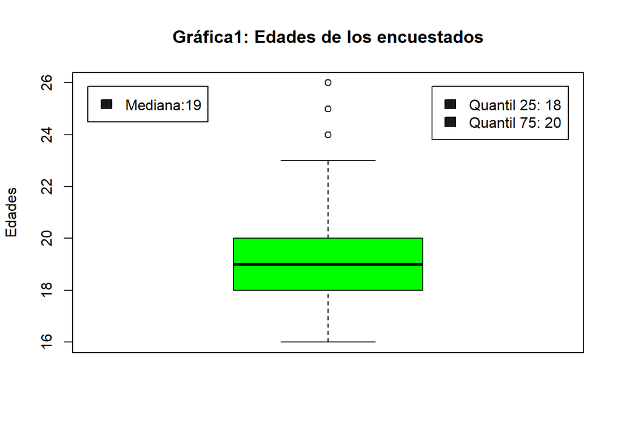

```r
boxplot(DDL$Edad, ylab="Edades", col="green", main="Gráfica1: Edades de los encuestados")

#Mediana:
mediana<-median(DDL$Edad, na.rm = T)
#Rango intercuantilico:
iqr<-IQR(DDL$Edad)
#Quantil 25:
quantil25<-quantile(DDL$Edad, 0.25)
#Quantil 25:75
quantil75<-quantile(DDL$Edad, 0.75)
desviacion_estandar<-sd(DDL$Edad)
varianza<-var(DDL$Edad)


legend("topleft", legend ="Mediana:19", # Posición y título
    fill = rgb(0, 0, 0, alpha = 0.9),  # Color
    inset = c(0.03, 0.05), # Cambiamos los márgenes
    bg = "white")
legend("topright", legend =c("Quantil 25: 18","Quantil 75: 20"), # Posición y título
    fill = rgb(0, 0, 0, alpha = 0.9),  # Color
    inset = c(0.03, 0.05), # Cambiamos los márgenes
    bg = "white")
```

**Mediana:**19

**Rango intercuantílico:**2

**Quantil 25:**18

**Quantili 75:**20

**Desviación Estándar:** 1.533864

**Varianza:** 2.352739

En la gráfica de cajas se expone las edades de los alumnos encuestados donde se puede inferir que la edad oscila entre los 18 años y 20 años.Por consiguiente,la edad céntrica de las edades los encuestados es de 19 años .Por último, se puede apreciar algunos edades que se salen del rango establecido que es entre 24 a 26 años , estás edad se presenta en pequeñas cantidades.

### Cursos Desaprobados

#### Gráfica 2

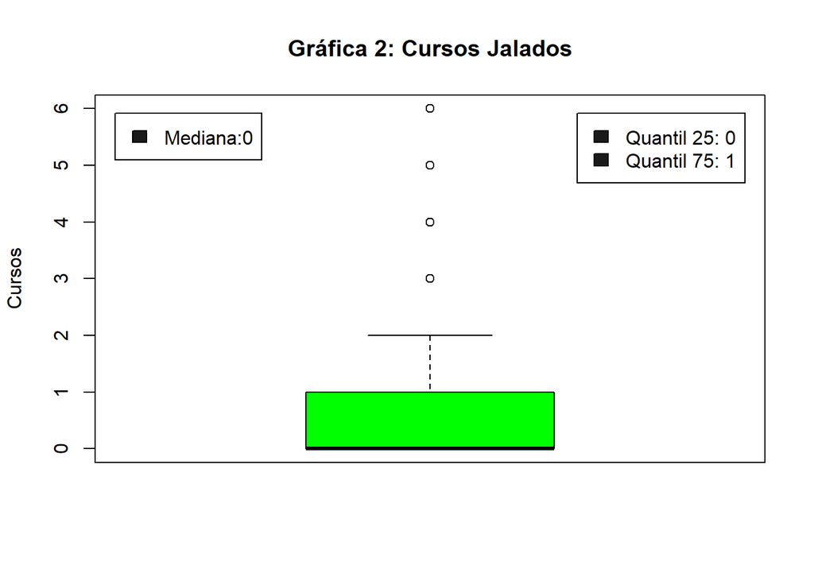

```r
boxplot(DDL$Cursos.jalados.retirados, ylab="Cursos", col="green", main="Gráfica 2: Cursos Jalados")

mediana<-median(DDL$Cursos.jalados.retirados, na.rm = T)
iqr<-IQR(DDL$Cursos.jalados.retirados)
quantil25<-quantile(DDL$Cursos.jalados.retirados, 0.25)
quantil75<-quantile(DDL$Cursos.jalados.retirados, 0.75)
varianza<-var(DDL$Cursos.jalados.retirados, na.rm = T)
desviacion_estandar<-sd(DDL$Cursos.jalados.retirados, na.rm = T)

legend("topleft", legend ="Mediana:0", # Posición y título
    fill = rgb(0, 0, 0, alpha = 0.9),  # Color
    inset = c(0.03, 0.05), # Cambiamos los márgenes
    bg = "white")
legend("topright", legend =c("Quantil 25: 0","Quantil 75: 1"), # Posición y título
    fill = rgb(0, 0, 0, alpha = 0.9),  # Color
    inset = c(0.03, 0.05), # Cambiamos los márgenes
    bg = "white")
```

**varianza: 1.49**

**desviación estándar: 1.22**

### Horas de estudio

#### Gráfica 3

```r
hist(DDL$Horas.estudio, main = "Gráfica 3: Horas de Estudio al día",
     ylab = "Personas encuestadas", xlab = "Horas", col="Gray")
mediana<- median(DDL$Horas.estudio, na.rm = T)
promedio<- mean(DDL$Horas.estudio, na.rm = T)
varianza<- var(DDL$Horas.estudio, na.rm = T)
desviacion_estandar<-sd(DDL$Horas.estudio, na.rm = T)
coeficiente_variación<-desviacion_estandar/promedio *100
coeficiente_variación
```

```
## [1] 44.00493
```

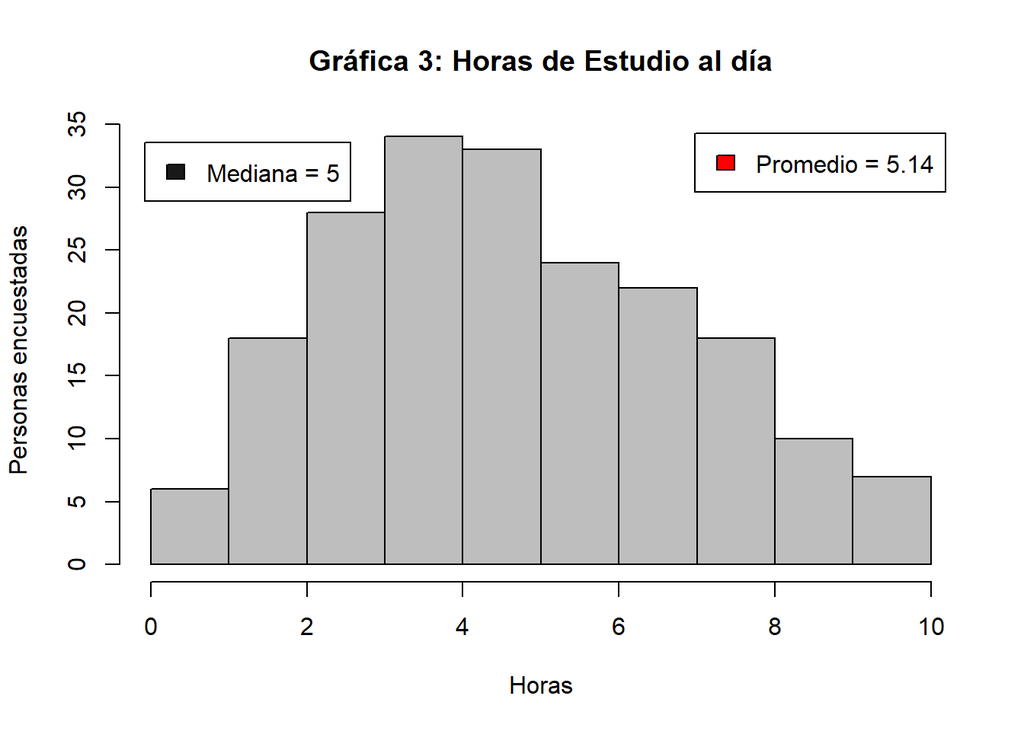

```r
legend("topleft", legend = "Mediana = 5",fill = rgb(0, 0, 0, alpha = 0.9),  # Color
    inset = c(0.03, 0.05), # Cambiamos los márgenes
    bg = "white")
legend("topright", legend = c("Promedio = 5.14"),fill = c("Red"),
    inset = c(0.02, 0.03), # Cambiamos los márgenes
    bg = "White")
```

**Rango Intercuartil:** 4

**Desviación estándar:** 2.26

**Varianza:** 5.12

**coeficiente de variación:** 44%

En la gráfica 3 cuya variables son las horas de estudio fuera de clases, de los estudiantes encuestados se logro reconocer que en promedio los estudiantes pasan estudiante 5.14 horas adicionales después de asistir a sus clases regulares.Por otro lado gracias a la mediana logramos determinar que el 50% de los alumnos estudia menos 5 horas al día y que el otro 50% de los alumnos estudia más de 5 horas. También se puede observar en la gráfica que hay alumnos que no estudian horas adicionales después de tener clases, pero también podemos decir que hay alumnos que incluso estudian 10 horas.

### Horas de estudio y género

#### Gráfica 4 y 5

```r
boxplot(DDL$Horas.estudio ~ DDL$Genero, main = "Gráfica 4: Horas de estudio vs Genero",
     ylab = "Horas de estudio", xlab = "Genero", col = "Gray")

legend("topright", legend = c("Promedio F= 5.70", "Promedio M= 4.68"), fill = c("Red", "Blue"), inset = c(0.03, 0.05), bg = "white")
ci.mean(DDL$Horas.estudio ~ DDL$Genero, data= DDL)
```

```
##  DDL$Genero mean CI-95%
##  Femenino   5.70 [5.23;6.17]
##  Masculino  4.68 [4.27;5.09]
```

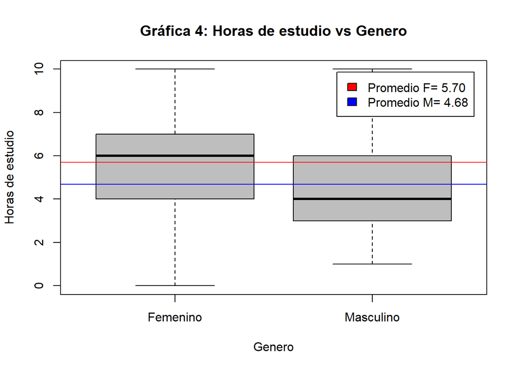

```r
abline(h= 5.70, col="Red")
abline(h= 4.68, col="Blue")
```

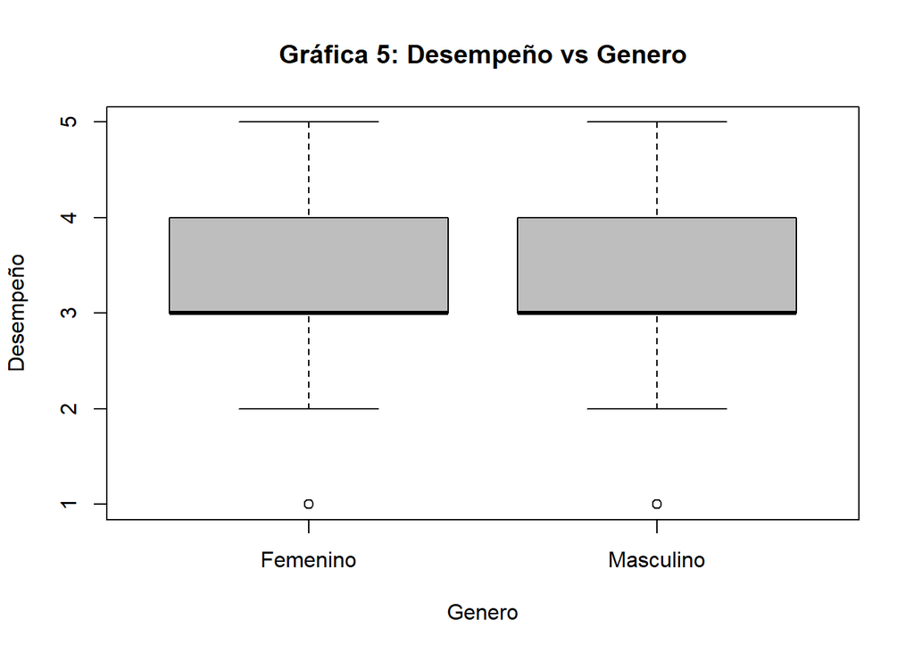

```r
boxplot(DDL$Desempenho ~ DDL$Genero, main = "Gráfica 5: Desempeño vs Genero",
     ylab = "Desempeño", xlab = "Genero", col = "Gray")
```

De acuerdo a la gráfica de “Horas de estudio vs Género” podemos saber que el género femenino estudia en promedio, 5 horas con 42 minutos, mientras que los hombres estudian en promedio, 4 horas con 41 minutos. Analizando estos valores podemos saber que las mujeres estudian 1 hora más que los hombres en promedio. Esta diferencia nos indicaría que las mujeres al estudiar más deberían tener mejor desempeño, pero lo que se vio en el estudio es que el desempeño de ambos géneros es igual.

## Descriptores gráficos

### Gráfica 6

#### Apreciación de el efecto de la pandemia en cada carrera:

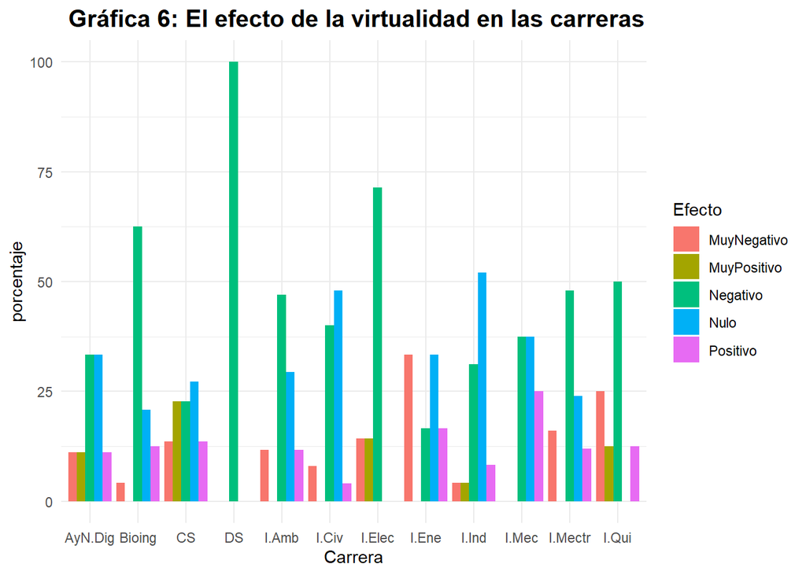

```r
tabla<-round(table(DDL$Carrera,DDL$Efecto.carrera)/rowSums(table(DDL$Carrera,DDL$Efecto.carrera))*100,digits=2)
Carrera<-c(rep("AyN.Dig",5), rep("Bioing",5),rep("DS",5),rep("CS",5),rep("I.Amb",5),rep("I.Civ",5),rep("I.Ene",5),rep("I.Elec",5),rep("I.Ind",5),rep("I.Mec",5),rep("I.Mectr",5),rep("I.Qui",5))
Efecto <- rep(c("MuyPositivo","Positivo","Nulo","MuyNegativo", "Negativo"),12)
porcentaje <- c(11.11,11.11,33.33,11.11,33.33,0.00,12.50,20.83,4.17,62.50,0.00,0.00,0.00,0.00,100.00,22.73,13.64,27.27,13.64,22.73,0.00,11.76,29.41,11.76,47.06,0.00,4.00,48.00,8.00,40.00,0.00,16.67,33.33,33.33,16.67,14.29,0.00,0.00,14.29,71.43,4.17,8.33,52.08,4.17,31.25,0.00,25.00,37.50,0.00,37.50,0.00,12.00,24.00,16.00,48.00,12.50,12.50,0.00,25.00,50.00)
Dato1<- data.frame(Carrera,Efecto,porcentaje)

ggplot(Dato1,aes(x=Carrera, y=porcentaje, fill=Efecto))+ geom_bar(position = "dodge", stat = "identity")+ theme_minimal() + labs(title = "Gráfica 6: El efecto de la virtualidad en las carreras") + theme(plot.title =element_text(size=15, face ='bold', hjust = 0.8))
```

### Gráfica 7

## Desempeño de los estudiantes:

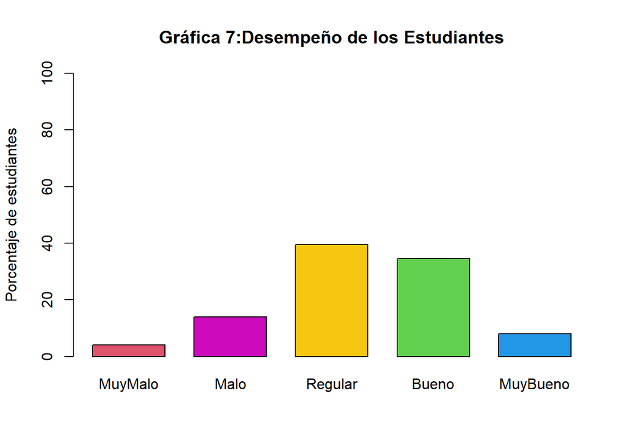

```r
tabla1<-table(DDL$Desempenho)/nrow(DDL)*100
barplot(tabla1,space=0.4,ylim = c(0,100), names.arg = c("MuyMalo","Malo","Regular", "Bueno", "MuyBueno"),main= "Gráfica 7:Desempeño de los Estudiantes", col=c(2,6,7,3,4), ylab= "Porcentaje de estudiantes")
```

### Gráfica 8

## Efectos de la pandemia en las carreras :

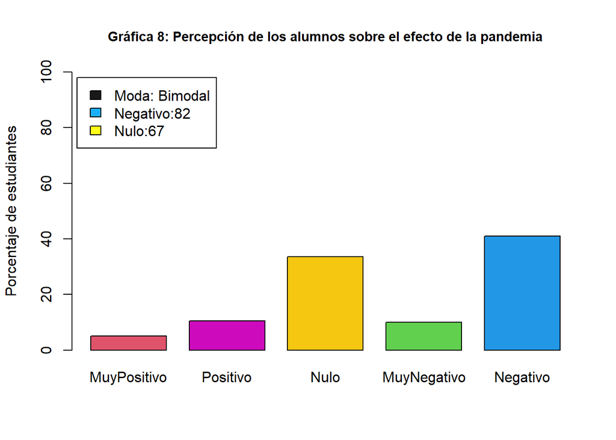

```r
tabla2<-table(DDL$Efecto.carrera)/nrow(DDL)*100
barplot(tabla2,space=0.3, width = 200, ylim=c(0,100),  names.arg = c("MuyPositivo", "Positivo", "Nulo", "MuyNegativo","Negativo"),main= "Gráfica 8: Percepción de los alumnos sobre el efecto de la pandemia", col=c(2,6,7,3,4), ylab= "Porcentaje de estudiantes" , cex.main = 0.9)
legend("topleft", legend =c("Moda: Bimodal","Negativo:82", "Nulo:67"), # Posición y título
    fill = c(rgb(0, 0, 0, alpha = 0.9),rgb(0, 0.66, 1, alpha = 0.9),rgb(1, 1, 0, alpha = 0.9)),  # Color
    inset = c(0.01, 0.02), # Cambiamos los márgenes
    bg = "white")
```

En esta gráfica de barras podemos predecir la proporcionalidad del total de personas encuestadas y las variables cualitativas que expresan la conformidad de la Educación en la pandemia. De acuerdo a ello se puede concluir que efecto que causó en la mayoría de estudiantes es disconforme, por otro lado también se presenta un cantidad regular de alumnos de los encuestados que no se vio perjudicado para bien o para mal. Estos resultados pueden ser relacionados al desempeño académico ya que la mayoría de los encuestados se encontró en disconformidad con sus carreras y esto pudo afectar su desempeño al no tener motivación.

### Gráfica 9:

## Problemas relacionados a la salud en los estudiantes

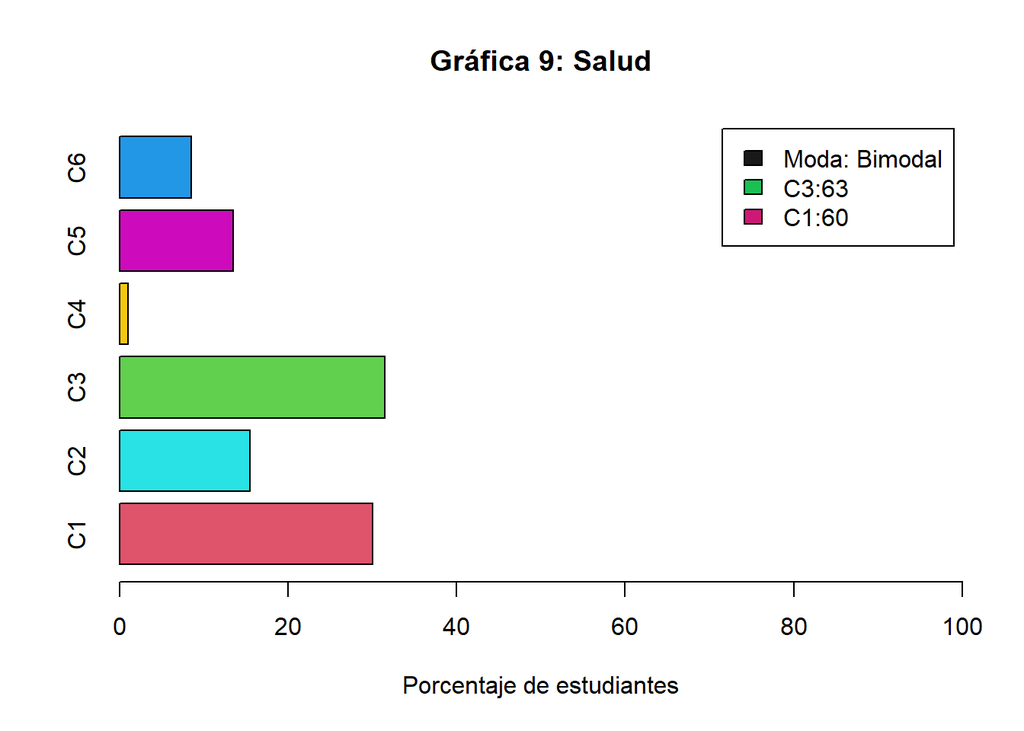

```r
tabla3<- table(DDL$Salud)/nrow(DDL) *100
barplot(tabla3,main= "Gráfica 9: Salud", xlim=c(0,100), horiz=T,names.arg = c("C1", "C2","C3","C4","C5","C6"),
col=c(2,5,3,7,6,4), xlab= "Porcentaje de estudiantes", axes=T)
legend("topright", legend =c("Moda: Bimodal","C3:63", "C1:60"), # Posición y título
    fill = c(rgb(0, 0, 0, alpha = 0.9),rgb(0, 0.73,0.26, alpha = 0.9),rgb(0.78, 0, 0.40, alpha = 0.9)),  # Color
    inset = c(0.01, 0.02), # Cambiamos los márgenes
    bg = "white")
```

### Gráfica 10

## Situación Economica

[figure not shown]

```r
tabla<-table(DDL$Situacion.economica, DDL$Efecto.desempenho)
situacion_economica<-c(rep("Clase Alta",3), rep("Clase Media",3), rep("Clase Baja", 3))
efecto_desempeño<-rep(c("Lo mejoró", "Se mantuvo igual", "Lo empeoró"),3)
proporciones<-c(1,6,2,9,24,30,21,58,49)
dato2<-data.frame(situacion_economica, efecto_desempeño, proporciones)

ggplot(dato2,aes(x=situacion_economica, y=proporciones, fill=efecto_desempeño))+ geom_bar(position = "fill", stat = "identity")+ labs(title = "Gráfica 10: La influencia de la situación económica en el desempeño") + theme(plot.title =element_text(size=10, face ='bold', hjust = 0.2))
```

### Gráfica 11

## Relación del desempeño de los alumnos con la cantidad de cursos desaprobados

```r
data<-table(X=DDL$Desempenho, Y=DDL$Cursos.jalados.retirados)

data1<-round(table(DDL$Desempenho,DDL$Cursos.jalados.retirados)/rowSums(table(DDL$Desempenho,DDL$Cursos.jalados.retirados))*100,digits=2)

# custom colors
new_colors <- colorRampPalette(c("cyan", "darkgreen"))
help("heatmap")
```

[output not shown]

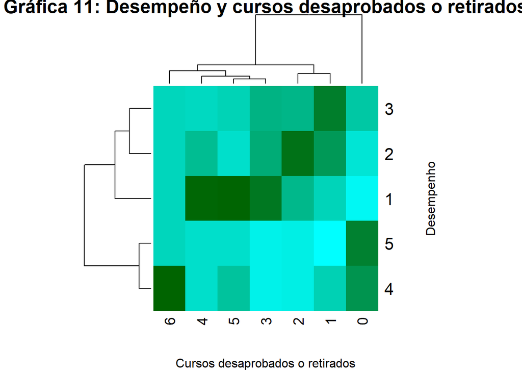

```r
# plotting the heatmap
plt <- heatmap(data1,
               # assigning new colors
               col = new_colors(100),

               # adding title
               main = "Gráfica 11: Desempeño y cursos desaprobados o retirados",

               # adding some margin so that
               # it doesn not drawn over the
               # y-axis label


               # adding x-axis labels
               xlab = "Cursos desaprobados o retirados",

               # adding y-axis labels
               ylab = "Desempenho",

               # to scaled the values into
               # column direction
               scale = "column"
)
```

## Análisis Probabilístico:

### Modelos:

#### Horas de estudio al día:

Una variable con distribución triangular

De la gráfica 3 pudimos observar que dicha variable presenta un comportamiento similar a una distribución triangular, ya que dicha distribución cuenta con un valor máximo, uno mínimo y una moda. En esta gráfica se puede ver que el valor mínimo sería 0 horas de estudio, el valor máximo 10 horas de estudio y la moda 4 horas de estudio. Para obtener dichos valores usamos una tabla de frecuencias.

```r
table(DDL$Horas.estudio)
```

```
##
##  0  1  2  3  4  5  6  7  8  9 10
##  1  5 18 28 34 33 24 22 18 10  7
```

La distribución triangular tiene 3 parámetros:

a = 0, b = 10, c = 4

**X: Horas de estudio al día** X -> Triangular(a = 0, b = 10, c = 4)

#### Pregunta 1:

```r
library(EnvStats)
(p1t<-ptri(9, 0,10,4) - ptri(5, 0, 10, 4))
```

```
## [1] 0.4
```

```r
round(p1t,2)*100
```

```
## [1] 40
```

#### Pregunta 2:

Además, también nos es útil saber las horas de estudio como máximo que tienen los alumnos en un porcentaje bajo, por eso planteamos la siguiente pregunta: Cuantas horas de estudio como máximo debería estudiar un alumno para tener una probabilidad de 36%? **P(X≤k) = 0.36**

```r
round(qtri(0.36, 0,10,4),2)
```

```
## [1] 3.79
```

### Cursos jalados o retirados:

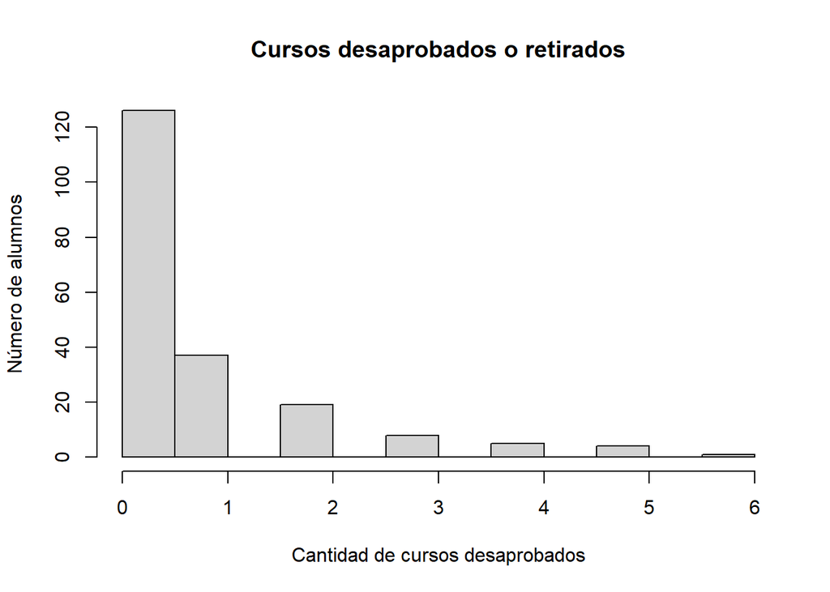

```r
hist(DDL$Cursos.jalados.retirados, main="Cursos desaprobados o retirados", ylab = "Número de alumnos", xlab = "Cantidad de cursos desaprobados")
```

```r
promedio<-(mean(DDL$Cursos.jalados.retirados, na.rm = T))
promedio
```

```
## [1] 0.725
```

```r
lambda<-1*3
p1p<-ppois(7,lambda)-ppois(3,lambda)
round(p1p,2)*100
```

```
## [1] 34
```

#### Pregunta2:

¿Cuantos cursos como máximo pueden desaprobar o retirarse los alumnos en un total de 3 ciclos si la probabilidad de es 91%? **P(X=<0.91)**

```r
lambda<-1*3
qpois(0.91,lambda)
```

```
## [1] 5
```

## Desempeño de los estudiantes

De la gráfica 7 extrajimos 2 casos que se asemejan, que los alumnos hayan tenido un desempeño bueno y muy bueno. Como estos son independientes aplicamos el 4to axioma de la probabilidad y sumamos sus porcentajes para reducirlos a una sólo variable que representa los casos de éxito de una distribución binomial.

```r
library(car)
DDL$Desempenho_agrupado<-recode(DDL$Desempenho, "4:5 ='optimo'; 1:3='no_optimo'")
table(DDL$Desempenho_agrupado)/200*100
```

```
##
## no_optimo    optimo
##      57.5      42.5
```

El porcentaje de alumnos que tuvieron un desempeño óptimo es de 42.5 % y esta sería nuestra probabilidad de éxito. De esta población de 200 encuestados extraemos a 50 alumnos para analizar y con esto podríamos modelar una distribución binomial con los siguientes parámetros: **X:Alumnos que tuvieron un desempeño óptimo.** **X->Binomial(n=50, p=0.425)**

#### Pregunta 1:

Habiendo recategorizado esta variable hemos dividido a la población en 2, en los que tienen un rendimiento óptimo y no óptimo, y si extraemos una muestra de 50 alumnos para poder hacer un estudio consideramos que es importante analizar rangos altos de estudiantes para saber cómo podría haberse comportado la población en cuanto a su desempeño. Es por eso que planteamos la siguiente pregunta: De la muestra de 50 alumnos, cuál sería la probabilidad de que haya entre 20 y 45 alumnos que hayan tenido un rendimiento óptimo en el periodo 2021-1 **P(20<X<45)**

```r
(p1b<-pbinom(44,50,0.425)-pbinom(20,50,0.425))
```

```
## [1] 0.5821153
```

```r
round(p1b,2)*100
```

```
## [1] 58
```

#### Pregunta 2:

Además, si sabemos que hay un 42.5% de alumnos que tuvieron un rendimiento óptimo, si queremos ver cuantos alumnos como mínimo deberían escogerse para que estemos casi en un 50% seguros que dichos alumnos tuvieron un rendimiento óptimos, nos serviría mucho la siguiente pregunta. De la muestra de 50 alumnos cuál sería la cantidad mínima de alumnos que tuvieron un rendimiento óptimo en el periodo 2021-1 si la probabilidad es de 0.468. **P(k≤X)=0.468**

```r
qbinom(0.468,50,0.425, lower.tail = F)
```

```
## [1] 22
```

### Tablas Cruzadas

#### Tabla Cruzada 1: Efecto de la virtualidad en la carrera vs Estado de ánimo

Como parte de la investigación estadística, al realizar las encuestas obtuvimos la siguiente información respecto a los efectos de la virtualidad en su carrera(BM=Beneficio mucho mi carrera, BP=Beneficio un poco mi carrera, NA=No afectó mi carrera, PP=Perjudicó un poco mi carrera, PM= Perjudicó mucho mi carrera) y cómo impactó eso en su estado de ánimo (1= muy mal estado de ánimo, 2= mal estado de ánimo, 3= ni mal ni buen estado de ánimo, 4= buen estado de ánimo, 5= muy buen estado de ánimo).

```r
table(DDL$Efecto.carrera, DDL$Estado.animo)
```

```
##
##                                 1  2  3  4  5
##   Beneficio mucho mi carrera    2  0  2  3  3
##   Beneficio un poco mi carrera  0  1  9  9  2
##   No afecto mi carrera          2 16 34 12  3
##   Perjudico mucho mi carrera    3  3 12  2  0
##   Perjudico un poco mi carrera  7 22 32 17  4
```

Pregunta 3: Considerando que en algunos casos la virtualidad beneficio mucho su carrera, cuál es la probabilidad de que tu estado de ánimo esté entre 4 y 5.

(P(4<= x <=5)/ BM) R ←(4<= x <=5) P(R/ BM) = P(R ∩ BM)/P(BM)

```r
R <- sum(3, 3)
BM <- sum(2, 0, 2, 3, 3)

(R/200)/(BM/200)
```

```
## [1] 0.6
```

Pregunta 4: De acuerdo a los datos hay diversas percepciones y esto podría estar influenciado por su estado de ánimo; por lo que nos hacemos la siguiente pregunta, cuál sería la probabilidad de que la virtualidad no haya afectado tu carrera o que su estado de ánimo haya sido 3. (PREGUNTA por la definición de esta variables) x: Estado de animo en 3 y No afecto mi carrera

E3 -> Estado de animo en 3

P(NA U E3) = (P(NA)+ P(E3) - P(NA ∩ E3))

```r
Na<- sum(2, 16, 34, 12, 3)
E3<- sum(2, 9, 34, 12, 32)

PNA = Na/200
PE3 = E3/200

PNA + PE3 - (34/200)
```

```
## [1] 0.61
```

## Tabla Cruzada 2: Salud vs Desempeño

Siguiendo con la investigación también obtuvimos la siguiente información respecto a problemas en la salud (AF=Algún familiar se vio afectado con el Covid-19, MC= Me contagié de Covid-19, NE=No sufrí ninguna enfermedad durante el periodo 2021-1, DA=Pasé por un deceso de un amigo cercano,DF=Pasé por un deceso familiar, TE=Tuve alguna otra enfermedad) y cómo impactó eso en su desempeño( D1= muy malo, D2= malo, D3= regular, D4= bueno, D5= muy bueno).

```r
table(DDL$Salud, DDL$Desempenho)
```

```
##
##                                                           1  2  3  4  5
##   AlgÃºn familiar se vio afectado con el Covid-19         2  4 30 22  2
##   Me contagiÃ© de Covid-19                                2  6 10 11  2
##   No sufrÃ ninguna enfermedad durante el periodo 2021-1  0  9 19 25 10
##   PasÃ© por un deceso de un amigo cercano                 0  0  1  1  0
##   PasÃ© por un deceso familiar                            2  5 11  8  1
##   Tuve alguna otra enfermedad                             2  4  8  2  1
```

Pregunta 5: Considerando que cuando estás pasando por el proceso de alguna enfermedad siempre te dificultará realizar bien tus actividades y más si eres estudiante por lo que tu desempeño no será la misma como cuando estás sano, dicho esto cuál es la probabilidad de que no me haya contagiado de covid ni su desempeño fue de “2”.

P(Me contagié de Covid-19 ∩ Desempeño 2 C) = P(MC U D2)C = 1 - P(MC U D2) 1- (P(MC)+ P(D2) - P(MC ∩ D2)

```r
MC <- sum(2, 6, 10, 11, 2)
D2 <- sum(4, 6, 9, 0, 5, 4)

PMC <- MC/200
PD2 <- D2/200
PMC_D2 <- (6/200)

round (1 - (PMC+ PD2 - PMC_D2),2)
```

```
## [1] 0.74
```

Pregunta 6: Como bien ya lo mencionamos no puedes pedire el mismo desempeño o rendimiento a una persona completamente sana que a una persona que está atravesando alguna enfermedad ya esta influencia de manera no positiva en la persona a la hora que realiza sus actividades, por ende tomando nuestra base de datos deseamos saber cual es la probabilidad de que su desempeño haya sido 1 y tuvo alguna otra enfermedad.

P(Desempeño 1 ∩ tuvo alguna otra enfermedad) = P(D1 ∩ TE) =(2 /200)

```r
PD1_TE = (2 /200)
PD1_TE
```

```
## [1] 0.01
```

### Tabla cruzada 3: Situación económica vs ¿Se mantuvieron las mismas horas de estudio pre-pandemia?

De acuerdo a la investigación realizada comparamos la clase económicas (alta, media y baja ) y las horas de estudio antes de la pandemia (prepandemia). Como sabemos la pandemia afectó mucho en el ámbito económico a diversas familias y esto pudo haber influenciado a los alumnos en su desempeño, y esto puede verse en si el alumno ha mantenido las mismas horas de estudio que tenía antes de la pandemia.

```r
table(DDL$Situacion.economica, DDL$Pre.pandemia)
```

```
##
##                No  Si
##   Clase Alta    4   5
##   Clase Baja   51  12
##   Clase Media 106  22
```

C.alta =4.5%

C.media =64 %

C.baja=31.5%

```r
prob_MEDIA<-c(0.64);
prob_BAJA<-c(0.315);
prob_ALTA<-c(0.045);
#ingreso de las probabilidades
probSiMEDIA<-0.17;
probNoMEDIA<-1 -0.17;
probSiBAJA<-0.19;
probNoBAJA<-1-0.19;
probSiALTA<-0.56;
probNoALTA<-1-0.56;
#Proba de q sea clase media cumple prepandemia
Probabilidad1<-probNoMEDIA*prob_MEDIA/sum(probNoMEDIA*prob_MEDIA,probNoBAJA*prob_BAJA,probNoALTA*prob_ALTA);
#Proba de q sea clase baja cumple hora prepandemia
Probabilidad2<-probNoBAJA*prob_BAJA/sum(probNoMEDIA*prob_MEDIA,probNoBAJA*prob_BAJA,probNoALTA*prob_ALTA);
#Proba de q sea clase altal cumple hora prepandemia
Probabilidad3<-probNoALTA*prob_ALTA/sum(probNoMEDIA*prob_MEDIA,probNoBAJA*prob_BAJA,probNoALTA*prob_ALTA);

A<-rbind(Probabilidad1,Probabilidad2,Probabilidad3);
A
```

```
##                     [,1]
## Probabilidad1 0.65893444
## Probabilidad2 0.31650437
## Probabilidad3 0.02456119
```

### **Bibliografía:**

#### I. (2021, 9 julio). Efectos del COVID-19 en la educación. Instituto Peruano de Economía[Efectos del COVID-19 en la educación](https://www.ipe.org.pe/portal/efectos-del-covid-19-en-la-educacion/)

#### II. (2020, agosto). La educación en tiempos de la pandemia de COVID-19. Comisión económica para América latina.[La educación en tiempos de la pandemia de COVID-19](https://www.cepal.org/es/publicaciones/45904-la-educacion-tiempos-la-pandemia-covid-19)

#### III. Vilela, P., Sánchez, J., & Chau, C. (2021). Desafíos de la educación superior en el Perú durante la pandemia por la covid-19. Desde el Sur, 13.[Desafíos de la educación superior en el Perú](http://www.scielo.org.pe/scielo.php?pid=S2415-09592021000200002&script=sci_abstract&tlng=en)